# Project Proposal

11/7/2017

## What I want to do / Who cares

- Paper Ohtsuki et al. (2006) "A simple rule for the evolution of cooperation on graphs"
- Networks as models to understand evolution/ natural selection (evolutionary graph theory)
- Interesting because it can help explain how characteristics (like cooperation) spread in a population based on fitness.
- **The network** :each node is a member of population, that plays an 'evolutionary game' with neighbours (so edge is relationship in terms of "game dynamic").
- each node has a fitness attribute, and a cooperator/defector attribute.

## General idea

- Fitness in this case is defined by :  
  \(\text{baseline} + bi-ck\), where i is number of neighbours who are also cooperators, and k number of neighbours.
- At each time, an individual dies and its spot is 'won' by either cooperator or defector
- With probability \(\frac{F_c}{(F_c+F_d)}\) the cooperator will win
- Ohtsuki hypothesis is that cooperation is favored by natural selection (spreads across network) if \(\frac{b}{c}>k\), where b is benefit, c is cost, and k is number of neighbours. I.e. at time t=n(nodes), all will be cooperators.

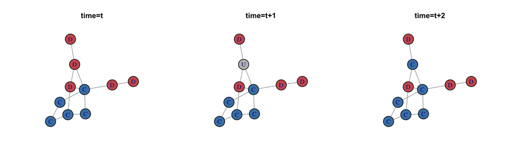

## Project, challenges and checks

- Othsuki et al. tested on model networks (e.g. circle network, lattice,…)
- For project, I want to reproduce simulation and test it on three "real life networks" (e.g. monks, fb network…)
- Q: how do characteristic of network initially influence end result?
- Challenges: Create proper simulation in that it updates network properly – define what b and c are
- Midterm success : test simulation on model graphs like in the paper.
- Final success : test simulation in existing "real life" networks, observe results.